# Stroke Survival Analysis - 2 Data Exploration

The JHS Analysis Dataset Warehouse dictionary was reviewed and variables were selected for further analysis/use in a survival analysis based on the CDC’s top risk factors which include: high blood pressure, high cholesterol, smoking, obesity and diabetes. Additionally, age is included, as risk increases with age.

## 2.1 Summary statistics

Table 2 provides descriptive statistics about selected variables based on the classification of stroke versus the adjudication of stroke and the stroke type.

### **Summary Statistics Based on Contact Type**

|  | Censored (N=2245) | Hemorrhagic Stroke (N=1) | Ischemic Stroke (N=42) | Overall (N=2288) |
| --- | --- | --- | --- | --- |
| Age in Years |  |  |  |  |
| Mean (SD) | 53.8 (11.7) | 59.2 (NA) | 63.8 (10.4) | 54.0 (11.7) |
| Median [Min, Max] | 53.6 [22.9, 83.2] | 59.2 [59.2, 59.2] | 65.3 [36.6, 83.1] | 53.9 [22.9, 83.2] |
| Hypertensive Status |  |  |  |  |
| Normal/Pre-Hypertensive | 1100 (49.0%) | 0 (0%) | 12 (28.6%) | 1112 (48.6%) |
| Hypertensive | 1145 (51.0%) | 1 (100%) | 30 (71.4%) | 1176 (51.4%) |
| Diabetes Categorization |  |  |  |  |
| Non-Diabetic | 1086 (48.4%) | 0 (0%) | 7 (16.7%) | 1093 (47.8%) |
| Pre-Diabetic | 792 (35.3%) | 1 (100%) | 18 (42.9%) | 811 (35.4%) |
| Diabetic | 367 (16.3%) | 0 (0%) | 17 (40.5%) | 384 (16.8%) |
| Smoking Status |  |  |  |  |
| Current Smoker | 275 (12.2%) | 0 (0%) | 9 (21.4%) | 284 (12.4%) |
| Never Smoked/Quit + 12 months | 1970 (87.8%) | 1 (100%) | 33 (78.6%) | 2004 (87.6%) |
| AHA BMI Categorization |  |  |  |  |
| Obese | 1211 (53.9%) | 0 (0%) | 22 (52.4%) | 1233 (53.9%) |
| Overweight | 743 (33.1%) | 1 (100%) | 15 (35.7%) | 759 (33.2%) |
| Normal Weight | 291 (13.0%) | 0 (0%) | 5 (11.9%) | 296 (12.9%) |
| AHA Total Cholesterol Categorization |  |  |  |  |
| Poor Health | 307 (13.7%) | 0 (0%) | 10 (23.8%) | 317 (13.9%) |
| Intermediate Health | 899 (40.0%) | 0 (0%) | 21 (50.0%) | 920 (40.2%) |
| Ideal Health | 1039 (46.3%) | 1 (100%) | 11 (26.2%) | 1051 (45.9%) |

### **Visuals**

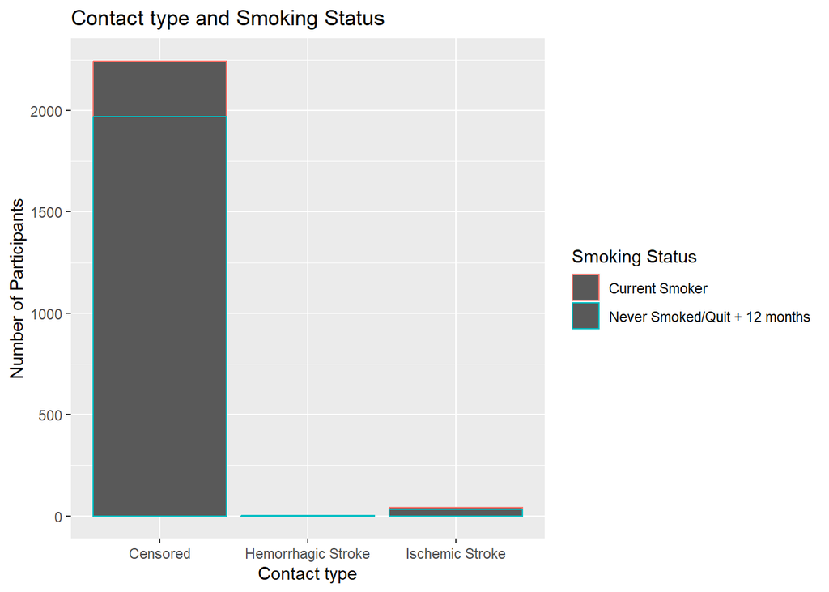

Note: Looking at the above plot it can be seen that the majority of current smokers were censored from the study.

The below plots illustrate how the individual variables trend (and change) throughout the study.

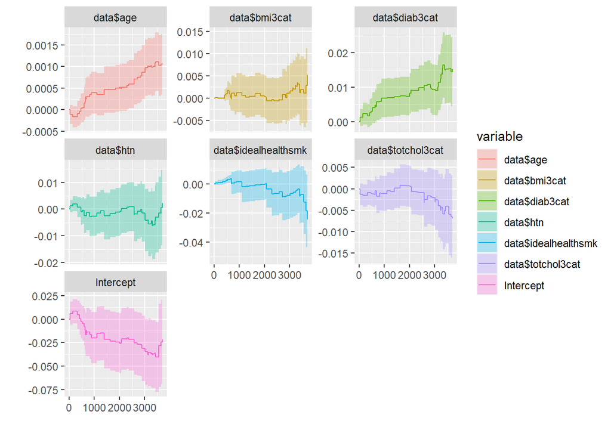

## 2.2 Data Dictionary

Two data sets were utilized and joined to create a final data set for analysis. Following are the variables used.

The time variable that will be utilized in the survival analysis is calculated using V1DATE and DATE from the adjudicated data set (incevtstroke). This calculated variable represents the event time which is the time from a participant joining the study until the participant either has a stroke or is censored from the study.

### **DATA SET:** Visit 1 Data (analysis1)

These data include observations from the participant’s first visit in the study.

[output not shown]

### **DATA SET:** Adjudicated Data (incevtstroke)

| **Variable Name** | **Definitions and Attributes** |
| --- | --- |
| SUBJID | - Subject identification number for participant |
| STROKE | - 0 = No stroke - 1 = Adjudication of stroke |
| V1DATE | Date of Exam 1 Clinic Visit |
| DATE | Event Date (stroke) or Censoring Date |
| CONTACTTYPE | ** Last Contact Type ** - Censored - Hemorrhagic Stroke - Ischemic Stroke - Previous Stroke History - Refused |